# Extracting Twitter Data

SICSS-Rutgers 2020

## A few examples of extracting tweets from Twitter

This document provides a few additional examples to supplement the process described in Chris Bail’s [video](https://www.youtube.com/watch?v=jde_c7pB5U8&feature=youtu.be) and in the Package features section [here](https://rtweet.info/).

You will need the package rtweet installed on your computer as well as a Twitter account. Note: to gain full functionality of this package, you will also need to apply for a developer’s API key.

- This [website](https://rtweet.info/) from Michael Kearney provides an overview of what functionality you can have with/without the API key

```
install.packages("rtweet")
```

Load the package

```r
library(rtweet)
```

Types of Twitter Information

- You can search and extract recent tweets that include keywords
- You can extract recent tweets from specific users
- You can extract information about whom a user follows/ who follows a user

## Search tweets with keywords

```r
## search for about 1000 tweets using "fauci"
fauci <- search_tweets(
  "fauci", n = 1000, include_rts = FALSE
)
```

You can take a look at a tweet here.

```r
fauci$text[1]
```

[output not shown]

## Extract recent tweets from a timeline

```r
## Let's get the 1000 most recent tweets from a few organizations
tvtweets <- get_timelines(c("netflix", "hulu", "hbomax"), n= 1000)
```

This is stored as a data frame with several columns.

```r
names(tvtweets)
```

```
##  [1] "user_id"                 "status_id"
##  [3] "created_at"              "screen_name"
##  [5] "text"                    "source"
##  [7] "display_text_width"      "reply_to_status_id"
##  [9] "reply_to_user_id"        "reply_to_screen_name"
## [11] "is_quote"                "is_retweet"
## [13] "favorite_count"          "retweet_count"
## [15] "quote_count"             "reply_count"
## [17] "hashtags"                "symbols"
## [19] "urls_url"                "urls_t.co"
## [21] "urls_expanded_url"       "media_url"
## [23] "media_t.co"              "media_expanded_url"
## [25] "media_type"              "ext_media_url"
## [27] "ext_media_t.co"          "ext_media_expanded_url"
## [29] "ext_media_type"          "mentions_user_id"
```

[output cut: 30 more lines]

Let’s take a look at how many tweets we have per org to make sure our call worked.

```r
table(tvtweets$screen_name)
```

```
##
##  hbomax    hulu netflix
##    1000     999     995
```

OK, let’s take a look at a tweet for fun:

```r
table(tvtweets$text[8])
```

```
##
## Happy Spike Day. #Da5Bloods is now on @netflix! https://t.co/ofOBBIgNJ2
##                                                                       1
```

## Plot a time series

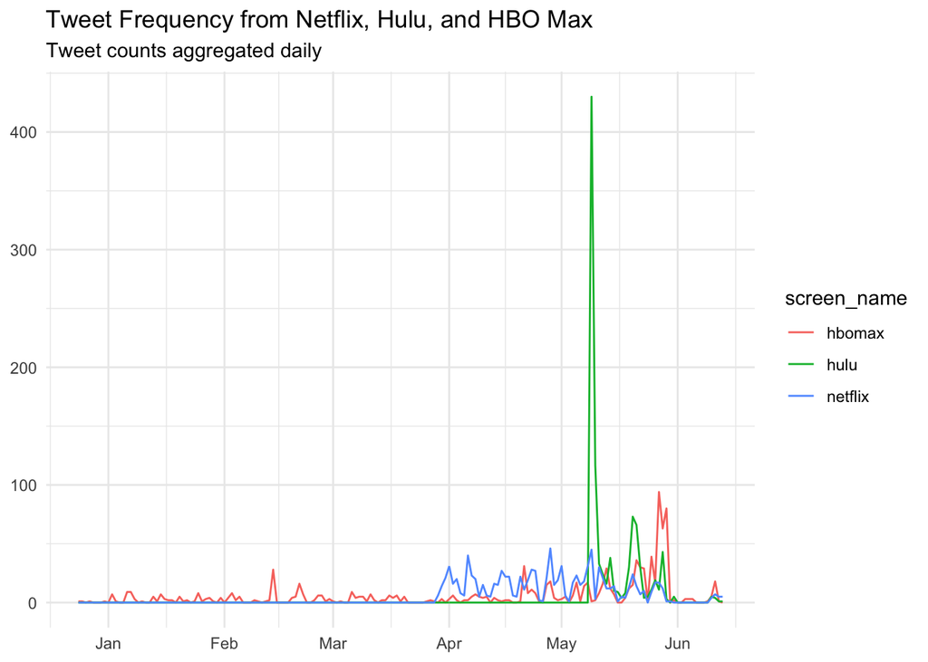

```r
## plot time series of tweets
library(ggplot2)
library(dplyr)

ts_plot(data = group_by(tvtweets, screen_name), by= "day") +
  theme_minimal() +
  labs(x = NULL, y = NULL,
    title = "Tweet Frequency from Netflix, Hulu, and HBO Max",
    subtitle = "Tweet counts aggregated daily")
```

## Extract a list of whom a user follows

Note: once you do this, you could, for example, feed these user names into the get_timelines() function.

```r
bills_friends <- get_friends("billgates")
```

## Extract a list of followers

```r
bills_followers <- get_followers("billgates", n= 1000)
```

Note: Due to API limits, we are restricted from retrieving all tweets (different functions have different limits) and also restricted in how much information we can extract at a given time.

The websites linked to above provide additional examples of mapping and plotting the tweets.